# Material suplementario

## 1 Paqueterías

```r
library(dagitty)
library(tidyverse)
library(DHARMa)
library(glmmTMB)
library(performance)
library(parameters)
library(gt)
library(AICcmodavg)
library(ggdag)
library(here)
```

## 2 DAGs - Directed Acyclic Graphic

Se planteó un gráfico acíclico dirigido (DAG - Directed Acyclic Graph) para describir la relación entre el índice de integridad ecosistémica (IE) (Equihua et al., 2014) y la diversidad y abundancia de pequeños mamíferos. Las relaciones se propusieron bajo la metodología de modelo Gráfico Causal (GCM - Graphical Causal Model) (Pearl, 2009; Schoolmaster Jr. et al., 2020). El GCM permite representar el conocimiento acerca del funcionamiento de un proceso como un diagrama causal e identificar qué observaciones mínimas son requeridas para estimar sin sesgos el efecto de una variable X en Y dada una estructura causal hipotética (Schoolmaster Jr. et al., 2020).

### 2.1 DAG - Abundancia pequeños mamíferos e integridad ecológica (IE)

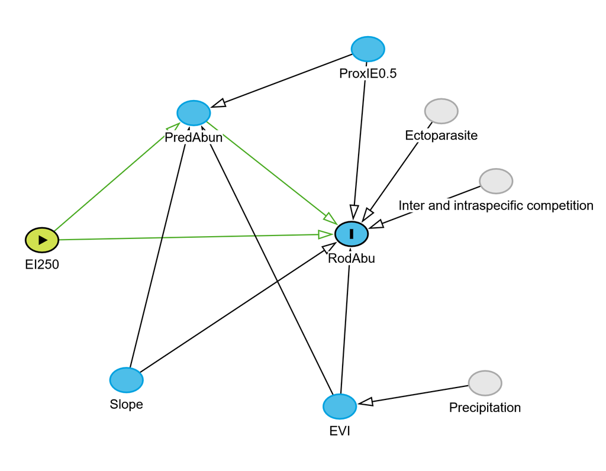

### 2.2 DAG - Diversidad pequeños mamíferos e integridad ecológica (IE)

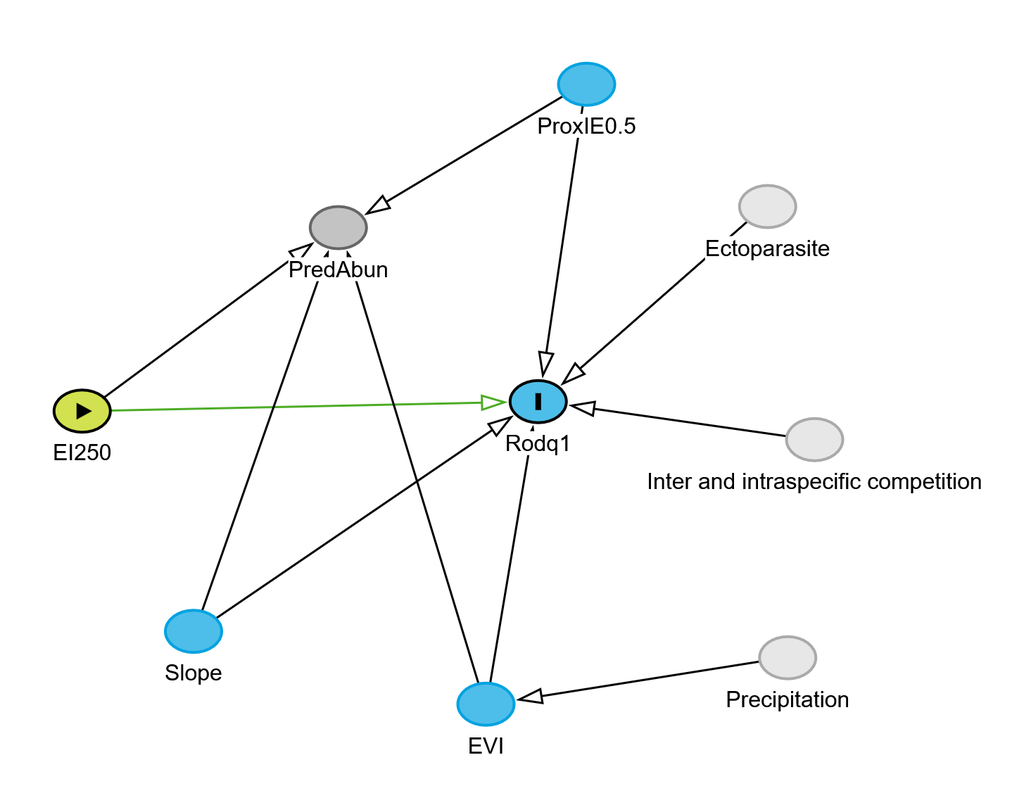

## 3 Coherencia del conjunto de datos DAG

Se realizó una prueba de consistencia del DAG, el cual contrasta los datos observacionales con las relaciones propuestas en el DAG. La prueba busca corroborar que las independencias condicionales entre las variables sean mantenidas en los datos. La prueba genera una correlación de Pearson para cada una de las independencias condicionales implicadas en el DAG. Un coeficiente de correlación cercano a cero con un p-value > 0.05 se obtiene si la independencia condicional se mantiene en los datos observacionales. En contraste, un alto valor de correlación y un p-value <0.05 indican que las independencias condicionales no se mantienen en los datos (Ankan et al., 2021).

### 3.1 Test consistencia del conjunto de datos DAG: abundancia

#### 3.1.1 Ajuste p-valor - Holm-Bonferroni correction

```
                  estimate    p.value        2.5%       97.5% Pvalue.Ad
EI25 _||_ EVI  -0.06797443 0.77894157 -0.49779319  0.38676788 1.0000000
EI25 _||_ PIE0  0.44964622 0.04586411  0.00889543  0.76479392 0.2491242
EI25 _||_ Slop -0.18668202 0.43607223 -0.58633339  0.27899259 1.0000000
EVI _||_ PIE0  -0.45766888 0.04152070 -0.77002643 -0.01899514 0.2491242
EVI _||_ Slop  -0.01555514 0.94885821 -0.45635524  0.43097753 1.0000000
PIE0 _||_ Slop  0.10074223 0.67683591 -0.35813574  0.52292048 1.0000000
```

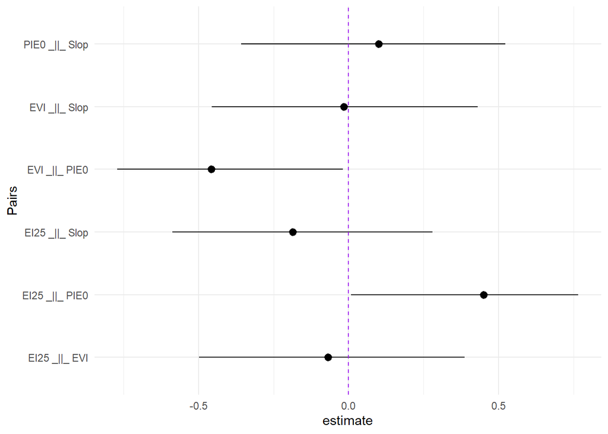

### 3.2 Test consistencia del conjunto de datos DAG: diversidad

#### 3.2.1 Ajuste p-valor - Holm-Bonferroni correction

```
                                          estimate    p.value        2.5%
EI25 _||_ EVI                          -0.06797443 0.77894157 -0.49779319
EI25 _||_ PIE0                          0.44964622 0.04586411  0.00889543
EI25 _||_ Slop                         -0.18668202 0.43607223 -0.58633339
EVI _||_ PIE0                          -0.45766888 0.04152070 -0.77002643
EVI _||_ Slop                          -0.01555514 0.94885821 -0.45635524
PrdA _||_ Rdq1 | EI25, EVI, PIE0, Slop -0.21254853 0.43644026 -0.64951231
PIE0 _||_ Slop                          0.10074223 0.67683591 -0.35813574
                                             97.5% Pvalue.Ad
EI25 _||_ EVI                           0.38676788 1.0000000
EI25 _||_ PIE0                          0.76479392 0.2906449
EI25 _||_ Slop                          0.27899259 1.0000000
EVI _||_ PIE0                          -0.01899514 0.2906449
EVI _||_ Slop                           0.43097753 1.0000000
PrdA _||_ Rdq1 | EI25, EVI, PIE0, Slop  0.31672371 1.0000000
PIE0 _||_ Slop                          0.52292048 1.0000000
```

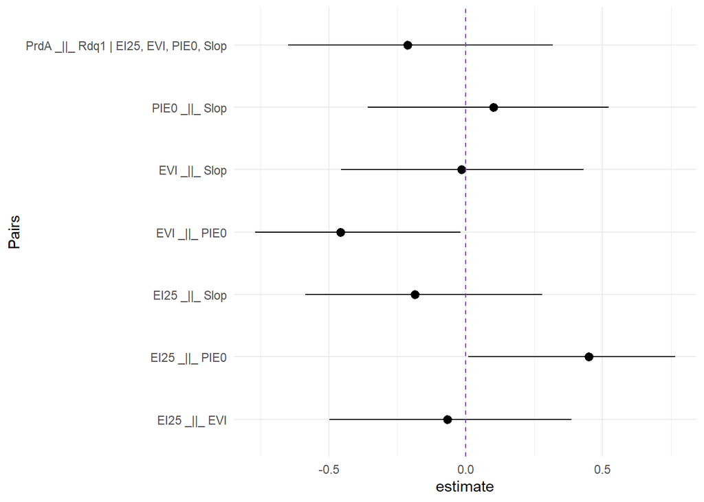

Tomando como base las relaciones propuestas en el DAG, y el test de consistencia del mismo, se evaluó el modelo que incluía la variable IE250 como único predictor de la abundancia y riqueza de PMNV. Lo anterior, siguiendo la aproximación causal evaluando el modelo con el mínimo número de variables que explicarían el efecto de la IE sobre la abundancia y diversidad de PMNV basado en el DAG (Arif and MacNeil 2023).

Adicionalmente, como ejercicio exploratorio, se ajustaron los modelos que podrían generarse con base a las variables del DAG siguiendo la aproximación Hipotetico Deductiva (HD) (Nichols and Cooch 2025). A partir del criterio de información de Akaike (AICc), se seleccionaron los modelos con un delta menor a dos para su posterior evaluación.

## 4 Modelos abundancia generales

### 4.1 Datos

```r
chap2 <- read.csv("~/INECOL/Doctorado/Proyecto2020/Capitulo 2/Analisis SEM/Data/dataSEM.csv", header = T) %>%
  drop_na()
```

### 4.2 Modelos

```r
# Modelos siguiendo el DAG

ModAbu1 <- (glmmTMB(RodAbu~IE250, data = chap2, family = nbinom2(), ziformula = ~1))
ModAbu2 <- (glmmTMB(RodAbu~IE250+PredAbun, data = chap2, family = nbinom2(),
                    ziformula = ~1))
ModAbu3 <- (glmmTMB(RodAbu~IE250+Slope, data = chap2, family = nbinom2(), ziformula = ~1))
ModAbu4 <- (glmmTMB(RodAbu~IE250+ProxIE0.5, data = chap2, family = nbinom2(), ziformula = ~1))
ModAbu5 <- (glmmTMB(RodAbu~IE250+EVI, data = chap2, family = nbinom2(), ziformula = ~1))
ModAbu6 <- (glmmTMB(RodAbu~PredAbun, data = chap2, family = nbinom2(), ziformula = ~1))
ModAbu7 <- (glmmTMB(RodAbu~EVI, data = chap2, family = nbinom2(), ziformula = ~1))
ModAbu8 <- (glmmTMB(RodAbu~ProxIE0.5, data = chap2, family = nbinom2(), ziformula = ~1, dispformula =~as.factor(Season)))
ModAbu9 <- (glmmTMB(RodAbu~as.factor(Cumulo), data = chap2, family = nbinom2(), ziformula = ~1))
```

```r
cand_Abun <- list(ModAbu1,ModAbu2,ModAbu3,ModAbu4,ModAbu5,ModAbu6,ModAbu7,ModAbu8, ModAbu9)
names_Abun <- c("RodAbu~IE250",
                "RodAbu~IE250+PredAbun",
                "RodAbu~IE250+Slope",
                "RodAbu~IE250+ProxIE0.5",
                "RodAbu~IE250+EVI",
                "RodAbu~PredAbun",
                "RodAbu~EVI",
                "RodAbu~ProxIE0.5",
                 "RodAbu~Cumulo"
                )

AICc_Abun <- aictab(cand_Abun,
                  modnames = names_Abun,
                  second.ord = T,
                  sort = T)
AICc_Abun
```

```
Model selection based on AICc:

                       K   AICc Delta_AICc AICcWt Cum.Wt     LL
RodAbu~ProxIE0.5       5 161.80       0.00   0.72   0.72 -73.76
RodAbu~Cumulo          4 165.11       3.31   0.14   0.86 -77.22
RodAbu~IE250+ProxIE0.5 5 167.39       5.59   0.04   0.90 -76.55
RodAbu~IE250           4 167.52       5.72   0.04   0.94 -78.43
RodAbu~PredAbun        4 169.27       7.47   0.02   0.96 -79.30
RodAbu~EVI             4 169.28       7.48   0.02   0.98 -79.31
RodAbu~IE250+EVI       5 170.60       8.80   0.01   0.99 -78.15
RodAbu~IE250+PredAbun  5 170.89       9.09   0.01   0.99 -78.30
RodAbu~IE250+Slope     5 171.12       9.32   0.01   1.00 -78.42
```

### 4.3 Modelo RodAbu~EI250

### 4.4 Test de dispersión y cero inflado

[output not shown]

#### 4.4.1 Test dispersión Modelo 1 RodAbu~EI250

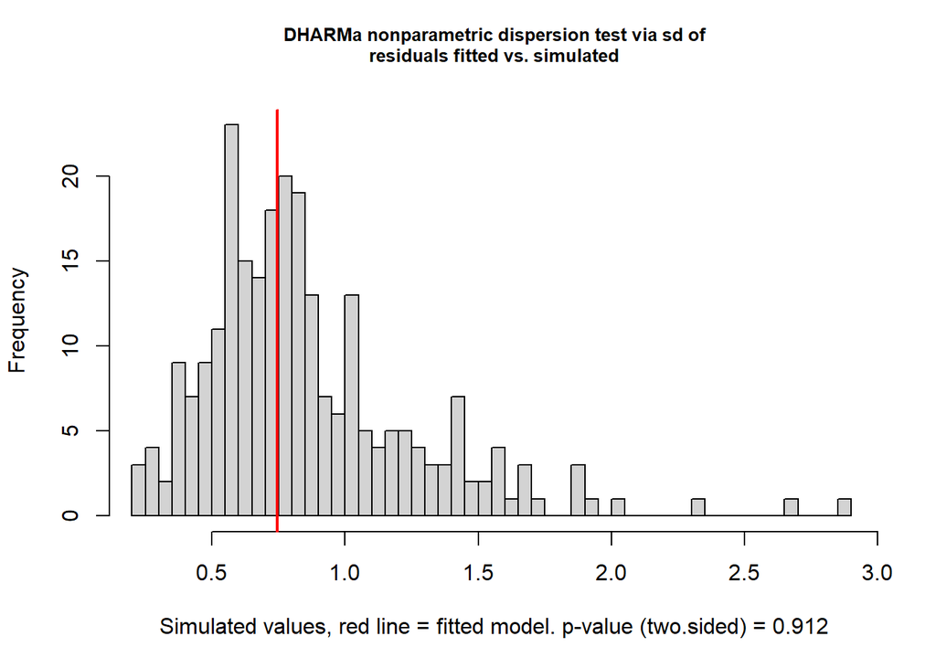

```
    DHARMa nonparametric dispersion test via sd of residuals fitted vs.
    simulated

data:  simulationOutput
dispersion = 0.8655, p-value = 0.912
alternative hypothesis: two.sided
```

```
qu = 0.25, log(sigma) = -2.44676 : outer Newton did not converge fully.
```

```
qu = 0.75, log(sigma) = -2.774019 : outer Newton did not converge fully.
```

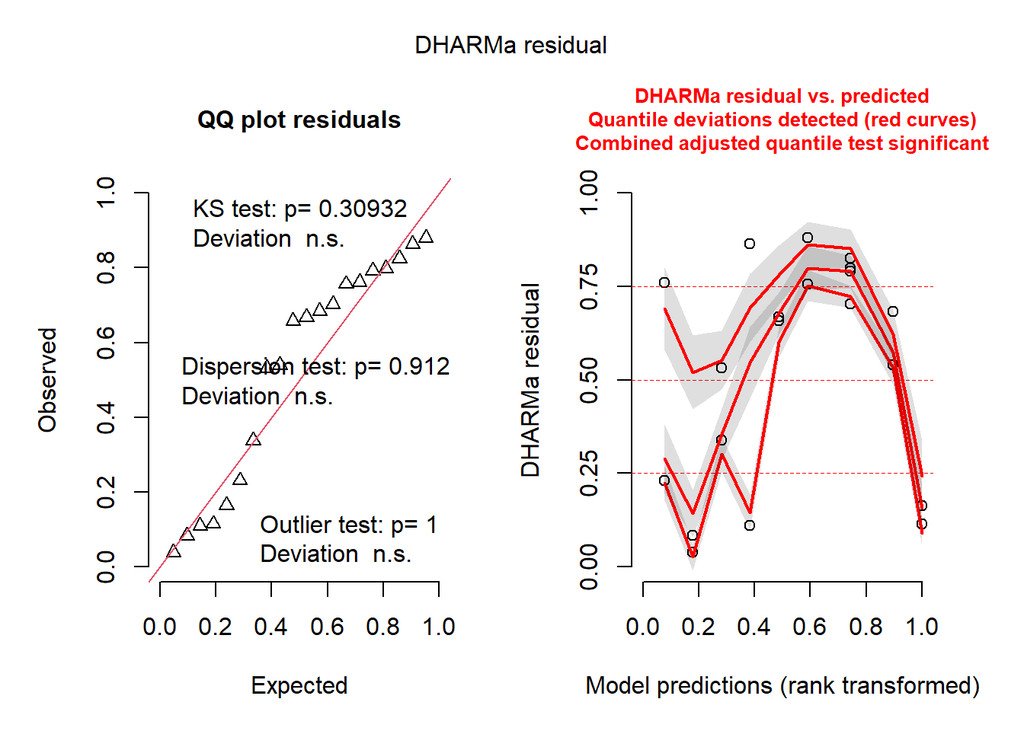

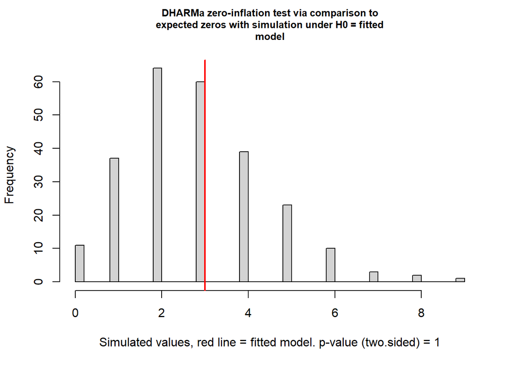

```
    DHARMa zero-inflation test via comparison to expected zeros with
    simulation under H0 = fitted model

data:  simulationOutput
ratioObsSim = 1.0388, p-value = 1
alternative hypothesis: two.sided
```

### 4.5 Modelo RodAbu~ProxIE0.5

| Parameter | Coefficient | SE | CI | CI_low | CI_high | z | df_error | p | Component | Effects |
| --- | --- | --- | --- | --- | --- | --- | --- | --- | --- | --- |
| (Intercept) | 2.4644015 | 0.2356894 | 0.95 | 2.0024588 | 2.9263442 | 10.4561408 | Inf | 1.373360e-25 | conditional | fixed |
| ProxIE0.5 | 22.7253296 | 5.6900307 | 0.95 | 11.5730745 | 33.8775848 | 3.9938853 | Inf | 6.499932e-05 | conditional | fixed |
| (Intercept) | -1.8177530 | 0.6837692 | 0.95 | -3.1579159 | -0.4775901 | -2.6584308 | Inf | 7.850547e-03 | zero_inflated | fixed |
| (Intercept) | 0.5473289 | 0.6427411 | 0.95 | -0.7124205 | 1.8070783 | 0.8515542 | Inf | 3.944616e-01 | dispersion | fixed |
| as.factor(Season)2 | 2.4133310 | 1.1739575 | 0.95 | 0.1124165 | 4.7142455 | 2.0557225 | Inf | 3.980927e-02 | dispersion | fixed |

#### 4.5.1 Test dispersión Modelo 8 RodAbu~Proxi EI0.5

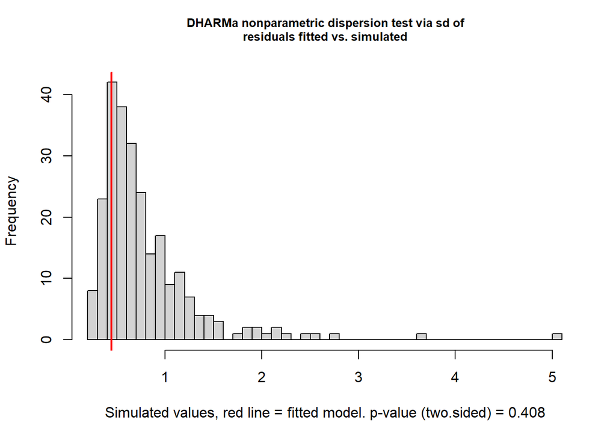

```
    DHARMa nonparametric dispersion test via sd of residuals fitted vs.
    simulated

data:  simulationOutput
dispersion = 0.56459, p-value = 0.408
alternative hypothesis: two.sided
```

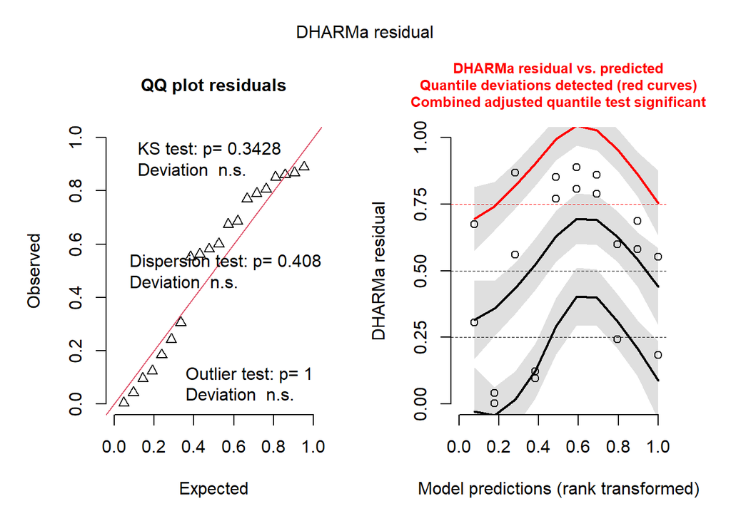

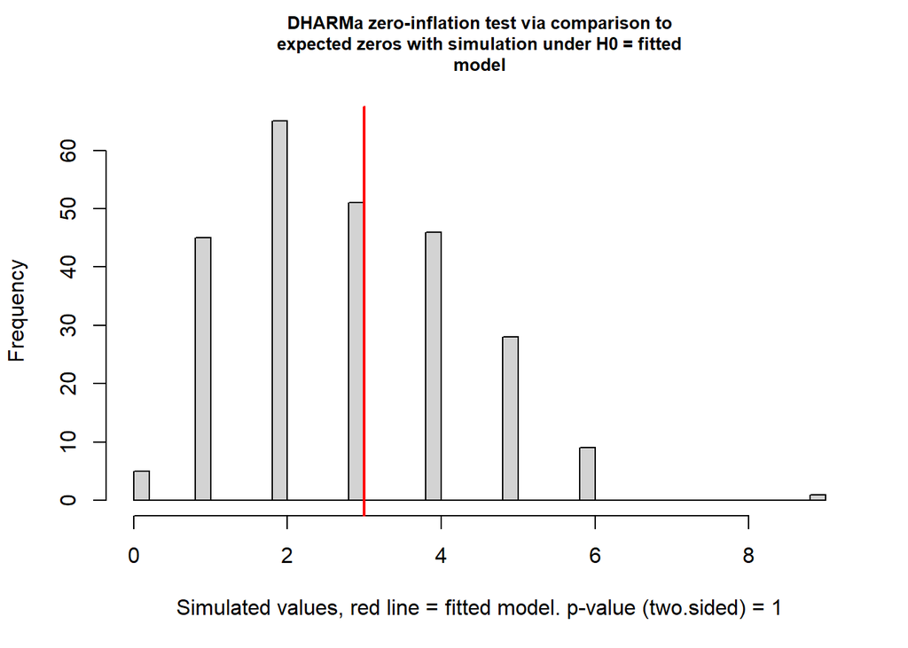

```
    DHARMa zero-inflation test via comparison to expected zeros with
    simulation under H0 = fitted model

data:  simulationOutput
ratioObsSim = 1.049, p-value = 1
alternative hypothesis: two.sided
```

## 5 Modelo de abundancia Peromyscus

### 5.1 Modelos abundancia Peromyscus

```r
ModPero1 <- (glmmTMB(AbuPero~IE250, data = chap2, family = nbinom2(), ziformula = ~1))
ModPero2 <- (glmmTMB(AbuPero~IE250+PredAbun, data = chap2, family = nbinom2(),
                    ziformula = ~1))
ModPero3 <- (glmmTMB(AbuPero~IE250+Slope, data = chap2, family = nbinom2(), ziformula = ~1))
ModPero4 <- (glmmTMB(AbuPero~IE250+ProxIE0.5, data = chap2, family = nbinom2(), ziformula = ~1))
ModPero5 <- (glmmTMB(AbuPero~IE250+EVI, data = chap2, family = nbinom2(), ziformula = ~1))
ModPero6 <- (glmmTMB(AbuPero~PredAbun, data = chap2, family = nbinom2(), ziformula = ~1))
ModPero7 <- (glmmTMB(AbuPero~EVI, data = chap2, family = nbinom2(), ziformula = ~1))
ModPero8 <- (glmmTMB(AbuPero~ProxIE0.5, data = chap2, family = nbinom2(), ziformula = ~1))
ModPero9 <- (glmmTMB(AbuPero~as.factor(Cumulo), data = chap2, family = nbinom2(), ziformula = ~1))
```

```r
cand_Abun_Pero  <- list(ModPero1,ModPero2,ModPero3,ModPero4,ModPero5,ModPero6,ModPero7,ModPero8,ModPero9)
names_Abun_Pero <- c("AbuPero~IE250",
                     "AbuPero~IE250+PredAbun",
                     "AbuPero~IE250+Slope",
                     "AbuPero~IE250+ProxIE0.5",
                     "AbuPero~IE250+EVI",
                     "AbuPero~PredAbun",
                     "AbuPero~EVI",
                     "AbuPero~ProxIE0.5",
                     "AbuPero~as.factor(Cumulo)"
                     )

AICc_Abun_Pero <- aictab(cand_Abun_Pero,
                  modnames = names_Abun_Pero,
                  second.ord = T,
                  sort = T)
AICc_Abun_Pero
```

```
Model selection based on AICc:

                          K   AICc Delta_AICc AICcWt Cum.Wt     LL
AbuPero~ProxIE0.5         4 132.76       0.00   0.27   0.27 -61.05
AbuPero~as.factor(Cumulo) 4 132.90       0.14   0.25   0.52 -61.12
AbuPero~IE250             4 134.22       1.47   0.13   0.65 -61.78
AbuPero~PredAbun          4 134.32       1.56   0.12   0.77 -61.82
AbuPero~EVI               4 134.85       2.09   0.09   0.87 -62.09
AbuPero~IE250+ProxIE0.5   5 136.36       3.60   0.04   0.91 -61.04
AbuPero~IE250+EVI         5 136.78       4.02   0.04   0.95 -61.25
AbuPero~IE250+PredAbun    5 137.41       4.65   0.03   0.97 -61.56
AbuPero~IE250+Slope       5 137.42       4.67   0.03   1.00 -61.57
```

### 5.2 Modelo AbuPero~IE250

| Parameter | Coefficient | SE | CI | CI_low | CI_high | z | df_error | p | Component | Effects |
| --- | --- | --- | --- | --- | --- | --- | --- | --- | --- | --- |
| (Intercept) | -1.300700 | 3.1428704 | 0.95 | -7.460613 | 4.8592130 | -0.4138573 | Inf | 0.678978624 | conditional | fixed |
| IE250 | 4.149038 | 3.6005627 | 0.95 | -2.907935 | 11.2060112 | 1.1523305 | Inf | 0.249185308 | conditional | fixed |
| (Intercept) | -1.801080 | 0.6671179 | 0.95 | -3.108607 | -0.4935534 | -2.6997934 | Inf | 0.006938255 | zero_inflated | fixed |
| (Intercept) | 3.212423 | NA | 0.95 | 1.215315 | 8.4913465 | NA | NA | NA | dispersion | fixed |

#### 5.2.1 Test dispersión y Zero inflado Modelos 1 AbuPero~IE250

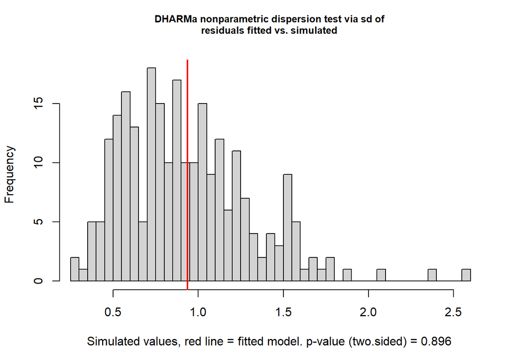

```
    DHARMa nonparametric dispersion test via sd of residuals fitted vs.
    simulated

data:  simulationOutput
dispersion = 1.0093, p-value = 0.896
alternative hypothesis: two.sided
```

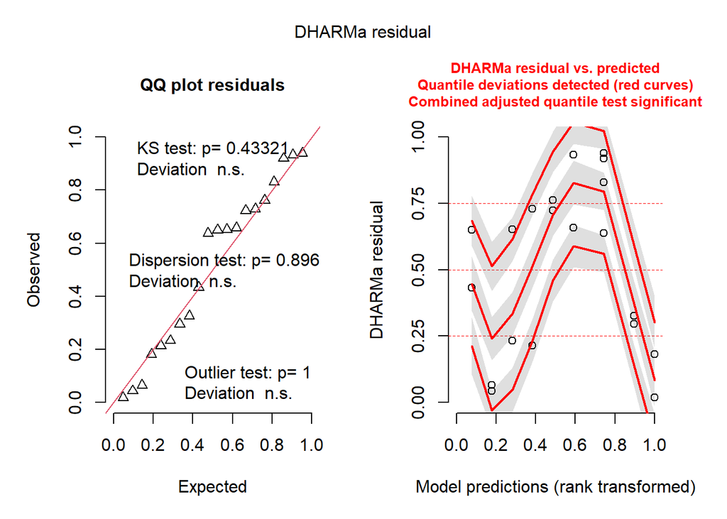

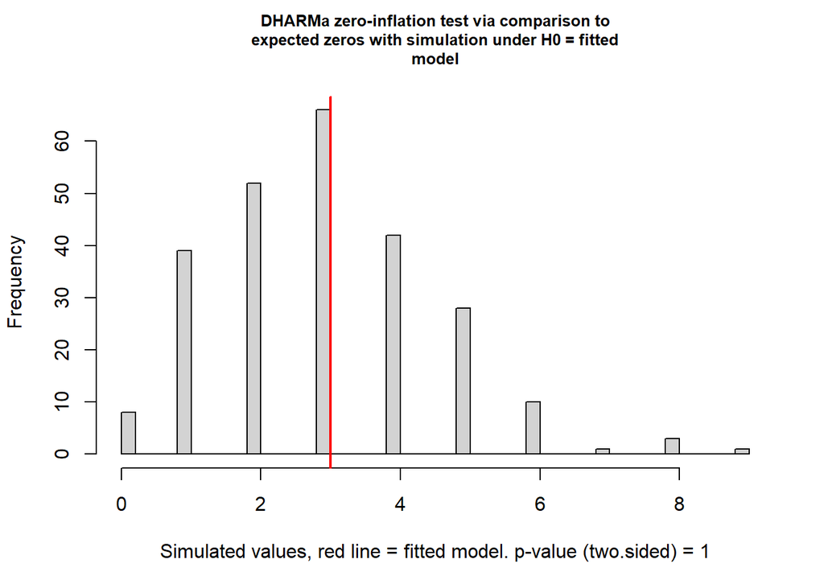

```
    DHARMa zero-inflation test via comparison to expected zeros with
    simulation under H0 = fitted model

data:  simulationOutput
ratioObsSim = 1.0013, p-value = 1
alternative hypothesis: two.sided
```

### 5.3 Modelo AbuPero~ProxIE0.5

#### 5.3.1 Test dispersión y Zero inflado Modelo 8 AbuPero~ProxIE0.5

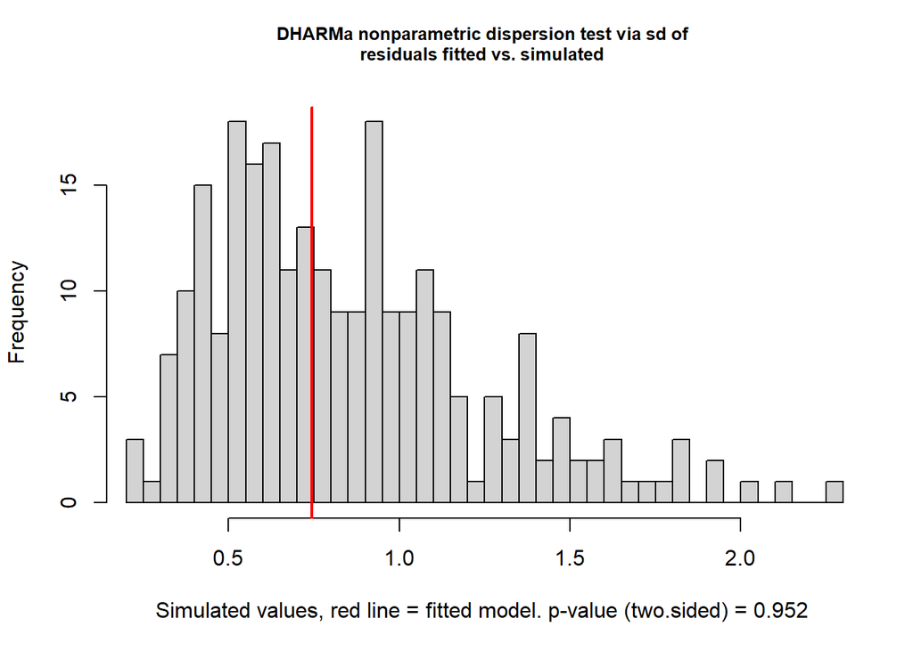

```
    DHARMa nonparametric dispersion test via sd of residuals fitted vs.
    simulated

data:  simulationOutput
dispersion = 0.87432, p-value = 0.952
alternative hypothesis: two.sided
```

```r
testDispersion(ModPero8)
```

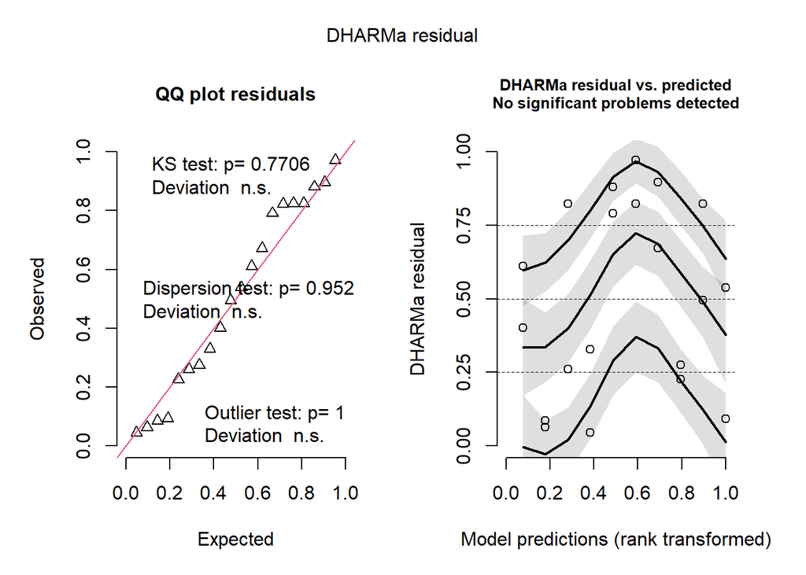

```r
ModPero8_residuals <- simulateResiduals(ModPero8)
plot(ModPero8_residuals)
```

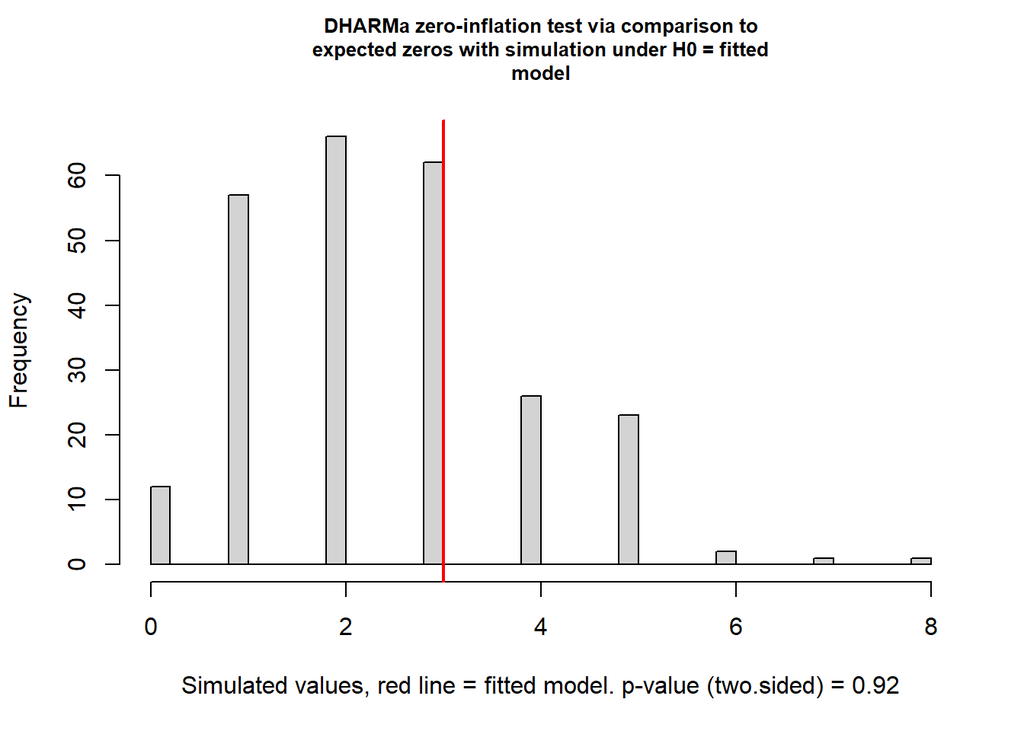

```
    DHARMa zero-inflation test via comparison to expected zeros with
    simulation under H0 = fitted model

data:  simulationOutput
ratioObsSim = 1.2077, p-value = 0.92
alternative hypothesis: two.sided
```

```r
testZeroInflation(ModPero8)
```

### 5.4 Modelo AbuPero~Cumulo

#### 5.4.1 Test dispersión y Zero inflado Modelo 9 AbuPero~Cumulo

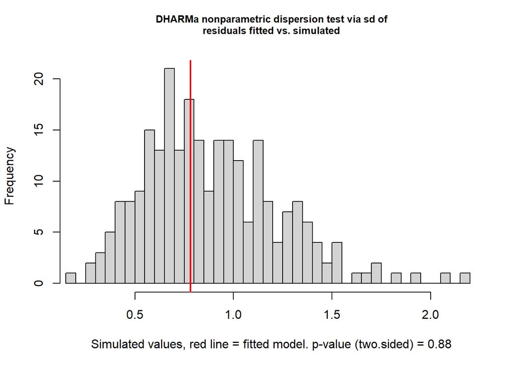

```
    DHARMa nonparametric dispersion test via sd of residuals fitted vs.
    simulated

data:  simulationOutput
dispersion = 0.8785, p-value = 0.88
alternative hypothesis: two.sided
```

```r
testDispersion(ModPero9)
```

```
 DHARMa: qgam was unable to calculate quantile regression for quantile 0.25. Possibly to few (unique) data points / predictions. The quantile will be ommited in plots and significance calculations.
```

```
 DHARMa: qgam was unable to calculate quantile regression for quantile 0.5. Possibly to few (unique) data points / predictions. The quantile will be ommited in plots and significance calculations.
```

```
 DHARMa: qgam was unable to calculate quantile regression for quantile 0.75. Possibly to few (unique) data points / predictions. The quantile will be ommited in plots and significance calculations.
```

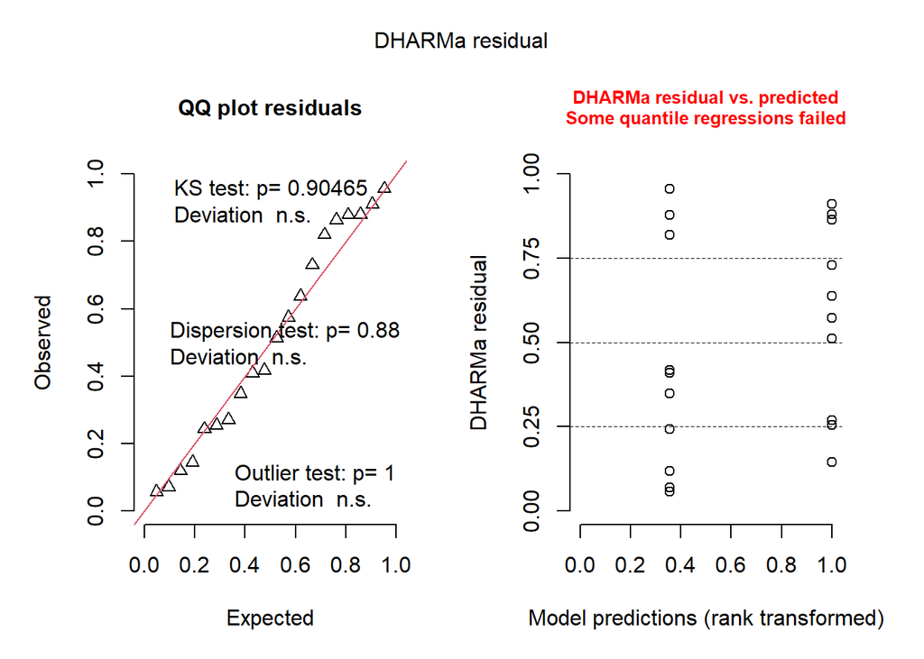

```r
ModPero9_residuals <- simulateResiduals(ModPero9)
plot(ModPero9_residuals)
```

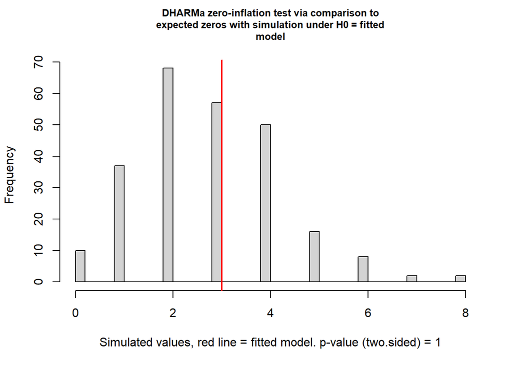

```
    DHARMa zero-inflation test via comparison to expected zeros with
    simulation under H0 = fitted model

data:  simulationOutput
ratioObsSim = 1.0684, p-value = 1
alternative hypothesis: two.sided
```

```r
testZeroInflation(ModPero9)
```

### 5.5 Modelo AbuPero~PredAbun

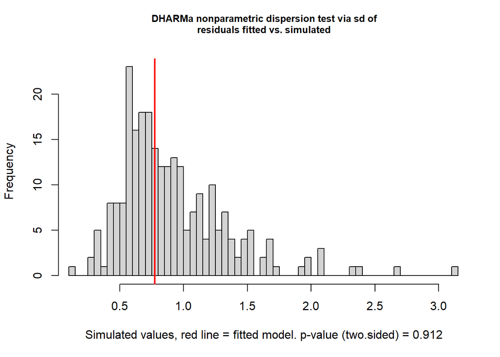

```
    DHARMa nonparametric dispersion test via sd of residuals fitted vs.
    simulated

data:  simulationOutput
dispersion = 0.84336, p-value = 0.912
alternative hypothesis: two.sided
```

```r
testDispersion(ModPero6)
```

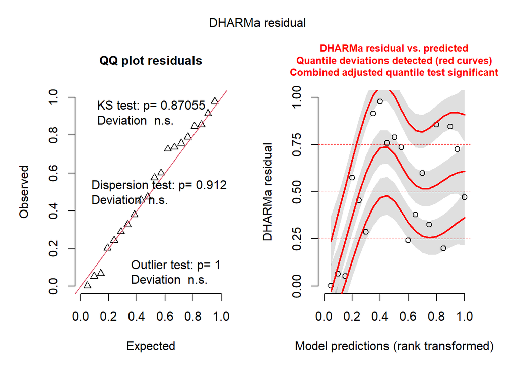

```r
ModPero6_residuals <- simulateResiduals(ModPero6)
plot(ModPero6_residuals)
```

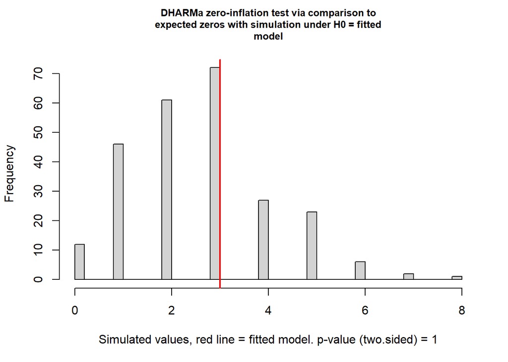

```
    DHARMa zero-inflation test via comparison to expected zeros with
    simulation under H0 = fitted model

data:  simulationOutput
ratioObsSim = 1.1278, p-value = 1
alternative hypothesis: two.sided
```

```r
testZeroInflation(ModPero6)
```

## 6 Modelos de diversidad

### 6.1 Riqueza q0

```r
Mod1_q0 <- (glmmTMB(Rodq0~IE250, data = chap2, ziformula = ~1, family = poisson))
Mod2_q0 <- (glmmTMB(Rodq0~IE250+Slope, data = chap2, ziformula = ~1, family = poisson()))
Mod3_q0 <- (glmmTMB(Rodq0~IE250+EVI, data = chap2, ziformula = ~1, family = poisson()))
Mod4_q0 <- (glmmTMB(Rodq0~IE250+Slope+EVI, data = chap2, ziformula = ~1, family = poisson()))
Mod5_q0 <- (glmmTMB(Rodq0~ProxIE0.5, data = chap2, ziformula = ~1, family = poisson()))
Mod6_q0 <- (glmmTMB(Rodq0~as.factor(Cumulo), data = chap2, ziformula = ~1, family = poisson()))
```

```r
cand_Divq0 <- list(Mod1_q0,Mod2_q0,Mod3_q0,Mod4_q0,Mod5_q0,Mod6_q0)
names_Divq0 <- c("Rodq0~IE250",
                 "Rodq0~IE250+Slope",
                 "Rodq0~IE250+EVI",
                 "Rodq0~IE250+Slope+EVI",
                 "Rodq0~ProxIE0.5",
                 "Rodq0~as.factor(Cumulo)"
)

AICc_Divq0 <- aictab(cand_Divq0,
                  modnames = names_Divq0,
                  second.ord = T,
                  sort = T)
AICc_Divq0
```

```
Model selection based on AICc:

                        K  AICc Delta_AICc AICcWt Cum.Wt     LL
Rodq0~ProxIE0.5         3 79.72       0.00   0.70   0.70 -36.11
Rodq0~as.factor(Cumulo) 3 82.87       3.14   0.15   0.85 -37.68
Rodq0~IE250             3 84.11       4.39   0.08   0.93 -38.30
Rodq0~IE250+EVI         4 85.22       5.49   0.05   0.97 -37.27
Rodq0~IE250+Slope       4 86.98       7.26   0.02   0.99 -38.16
Rodq0~IE250+Slope+EVI   5 88.59       8.87   0.01   1.00 -37.15
```

### 6.2 Modelo Rodq0~IE250

```r
gt(parameters(Mod1_q0))
```

| Parameter | Coefficient | SE | CI | CI_low | CI_high | z | df_error | p | Component | Effects |
| --- | --- | --- | --- | --- | --- | --- | --- | --- | --- | --- |
| (Intercept) | -1.953898 | 2.5793788 | 0.95 | -7.009387 | 3.1015917 | -0.7575071 | Inf | 0.4487461 | conditional | fixed |
| IE250 | 3.623307 | 2.9336526 | 0.95 | -2.126546 | 9.3731605 | 1.2350839 | Inf | 0.2167993 | conditional | fixed |
| (Intercept) | -1.971065 | 0.7717834 | 0.95 | -3.483732 | -0.4583971 | -2.5539093 | Inf | 0.0106521 | zero_inflated | fixed |

#### 6.2.1 Test dispersión Modelo Rodq0~IE250

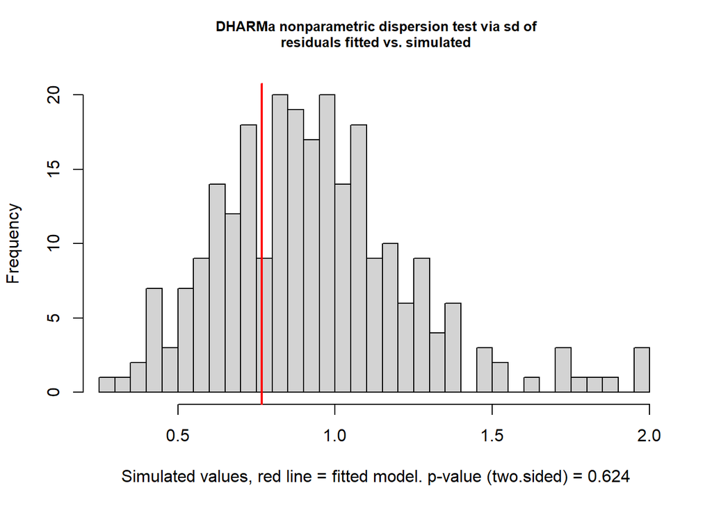

```
    DHARMa nonparametric dispersion test via sd of residuals fitted vs.
    simulated

data:  simulationOutput
dispersion = 0.82281, p-value = 0.624
alternative hypothesis: two.sided
```

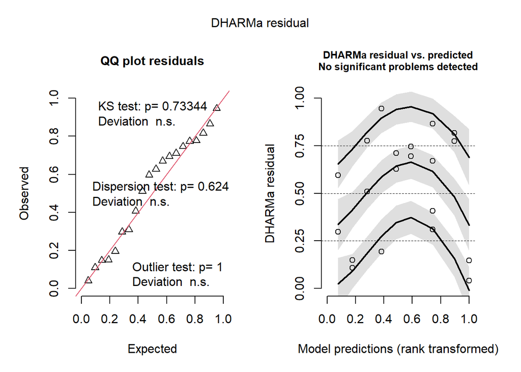

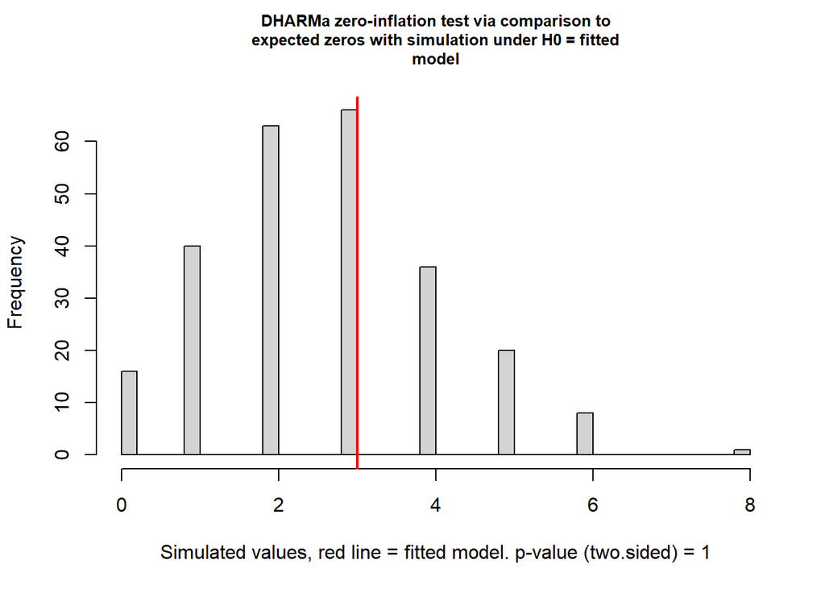

```
    DHARMa zero-inflation test via comparison to expected zeros with
    simulation under H0 = fitted model

data:  simulationOutput
ratioObsSim = 1.1295, p-value = 1
alternative hypothesis: two.sided
```

### 6.3 Modelo Rodq0~ProxIE0.5

```r
gt(parameters(Mod5_q0))
```

| Parameter | Coefficient | SE | CI | CI_low | CI_high | z | df_error | p | Component | Effects |
| --- | --- | --- | --- | --- | --- | --- | --- | --- | --- | --- |
| (Intercept) | 0.2987681 | 3.196481e-01 | 0.95 | -3.277307e-01 | 9.252668e-01 | 0.934678132 | Inf | 0.349954200 | conditional | fixed |
| ProxIE0.5 | 21.8724745 | 7.396416e+00 | 0.95 | 7.375766e+00 | 3.636918e+01 | 2.957172038 | Inf | 0.003104748 | conditional | fixed |
| (Intercept) | -20.6311424 | 1.835003e+04 | 0.95 | -3.598603e+04 | 3.594477e+04 | -0.001124311 | Inf | 0.999102930 | zero_inflated | fixed |

#### 6.3.1 Test dispersión Modelo Rodq0~ProxIE0.5

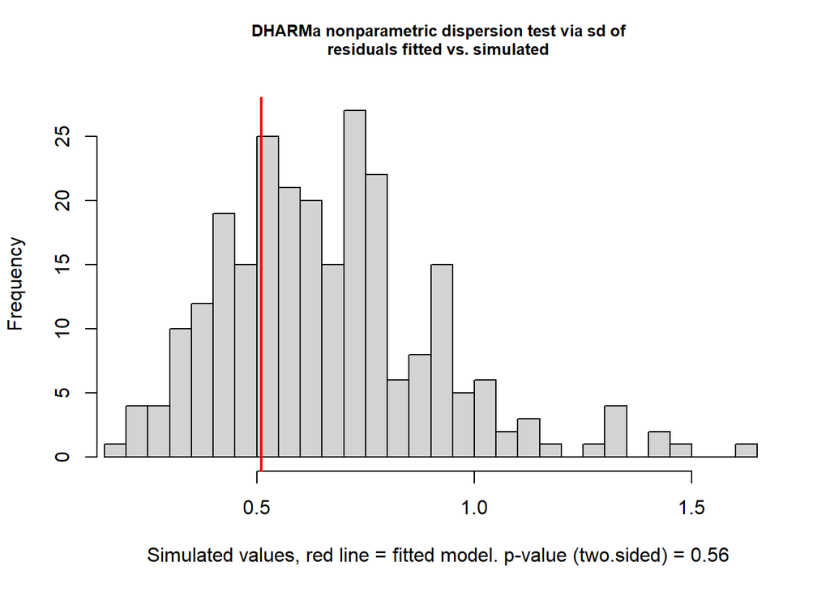

```
    DHARMa nonparametric dispersion test via sd of residuals fitted vs.
    simulated

data:  simulationOutput
dispersion = 0.7678, p-value = 0.56
alternative hypothesis: two.sided
```

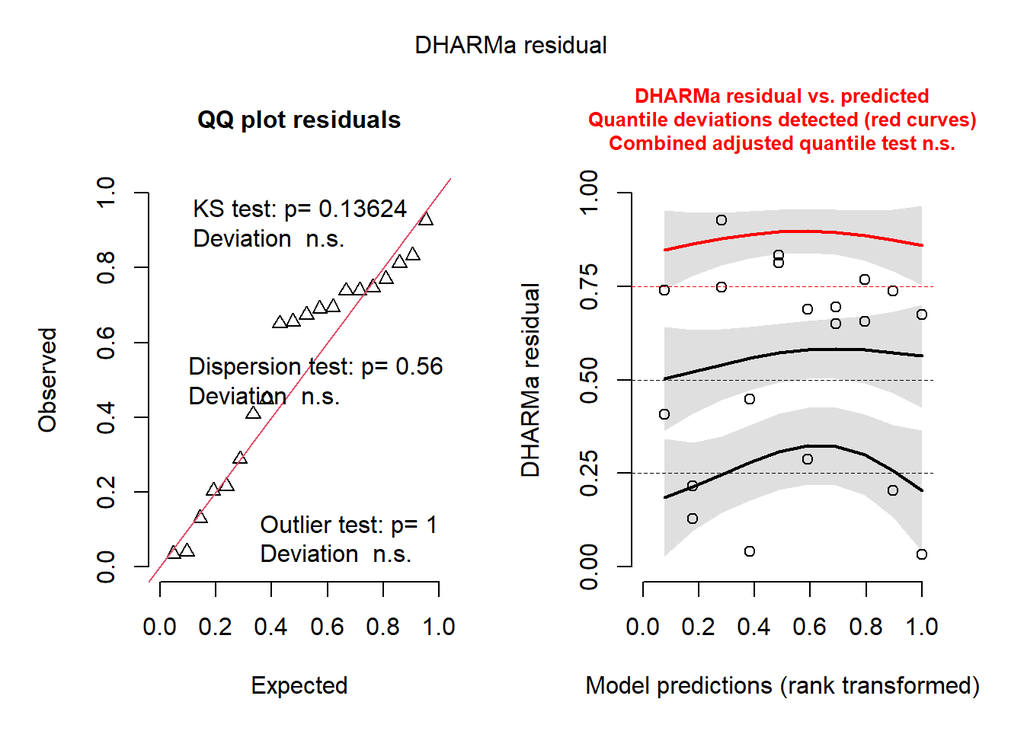

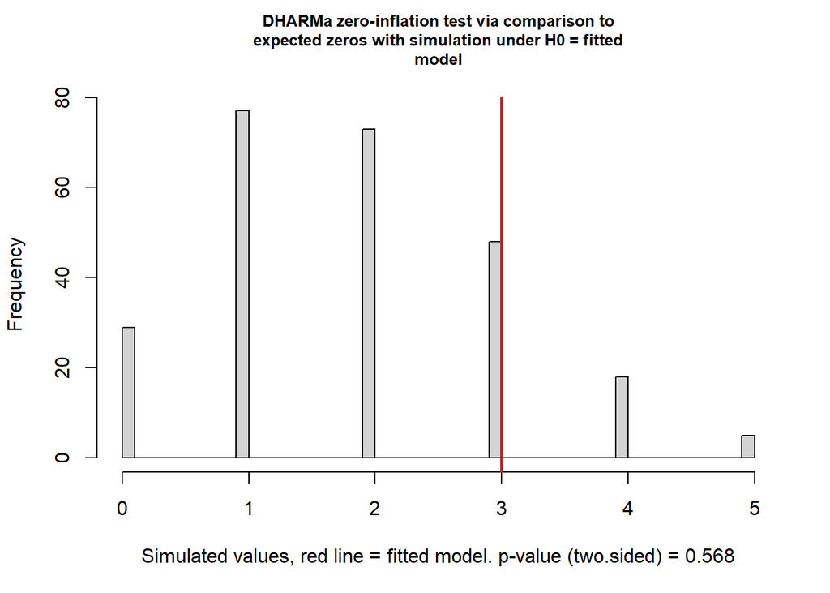

```
    DHARMa zero-inflation test via comparison to expected zeros with
    simulation under H0 = fitted model

data:  simulationOutput
ratioObsSim = 1.6164, p-value = 0.568
alternative hypothesis: two.sided
```

### 6.4 q1 Diversidad de especies

#### 6.4.1 Modelos

```r
Mod1_q1 <- (glmmTMB(Rodq1~IE250, data = chap2, ziformula= ~1,family = gaussian()))
Mod2_q1 <- (glmmTMB(Rodq1~ProxIE0.5, data = chap2, ziformula= ~1,family = gaussian()))
Mod3_q1 <- (glmmTMB(Rodq1~IE250+Slope, data = chap2, ziformula= ~1,family = gaussian()))
Mod4_q1 <- (glmmTMB(Rodq1~IE250+EVI, data = chap2, ziformula= ~1,family = gaussian()))
Mod5_q1 <- (glmmTMB(Rodq1~IE250+Slope+EVI, data = chap2, ziformula= ~1,family = gaussian()))
Mod6_q1 <- (glmmTMB(Rodq1~as.factor(Cumulo), data = chap2, ziformula= ~1,family = gaussian()))
```

```r
cand_Divq1 <- list(Mod1_q1,Mod2_q1,Mod3_q1,Mod4_q1,Mod5_q1,Mod6_q1)
names_Divq1 <- c("Rodq1~IE250",
                 "Rodq1~ProxIE0.5",
                 "Rodq1~IE250+Slope",
                 "Rodq1~IE250+EVI",
                 "Rodq1~IE250+Slope+EVI",
                 "Rodq1~as.factor(Cumulo)"
)

AICc_Divq1 <- aictab(cand_Divq1,
                  modnames = names_Divq1,
                  second.ord = T,
                  sort = T)
AICc_Divq1
```

```
Model selection based on AICc:

                        K  AICc Delta_AICc AICcWt Cum.Wt     LL
Rodq1~ProxIE0.5         4 70.60       0.00   0.47   0.47 -29.97
Rodq1~IE250             4 72.05       1.45   0.23   0.70 -30.69
Rodq1~as.factor(Cumulo) 4 73.19       2.59   0.13   0.82 -31.26
Rodq1~IE250+EVI         5 73.93       3.33   0.09   0.91 -29.82
Rodq1~IE250+Slope       5 74.50       3.90   0.07   0.98 -30.11
Rodq1~IE250+Slope+EVI   6 76.93       6.33   0.02   1.00 -29.24
```

### 6.5 Modelo Rodq1~IE250

| Parameter | Coefficient | SE | CI | CI_low | CI_high | z | df_error | p | Component | Effects |
| --- | --- | --- | --- | --- | --- | --- | --- | --- | --- | --- |
| (Intercept) | -3.1992071 | 3.5896481 | 0.95 | -10.2347881 | 3.836374 | -0.8912314 | Inf | 0.372805044 | conditional | fixed |
| IE250 | 6.8492506 | 4.1189642 | 0.95 | -1.2237708 | 14.922272 | 1.6628575 | Inf | 0.096340955 | conditional | fixed |
| (Intercept) | -1.7671059 | 0.6458261 | 0.95 | -3.0329017 | -0.501310 | -2.7361946 | Inf | 0.006215427 | zero_inflated | fixed |
| (Intercept) | 0.9155938 | NA | 0.95 | 0.6378874 | 1.314201 | NA | NA | NA | dispersion | fixed |

#### 6.5.1 Test dispersión - Modelo Rodq1~IE250

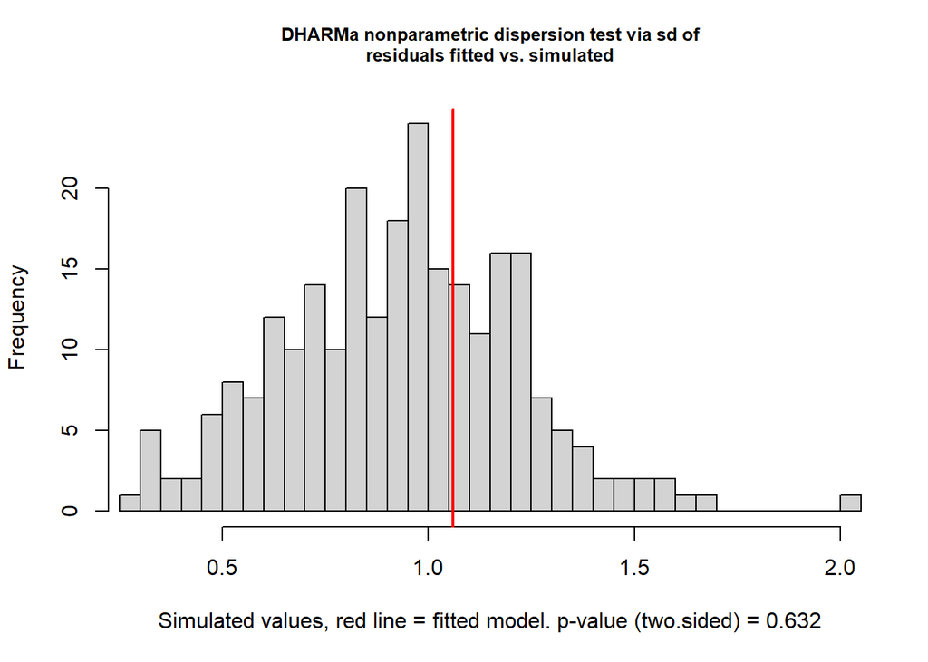

```
    DHARMa nonparametric dispersion test via sd of residuals fitted vs.
    simulated

data:  simulationOutput
dispersion = 1.1353, p-value = 0.632
alternative hypothesis: two.sided
```

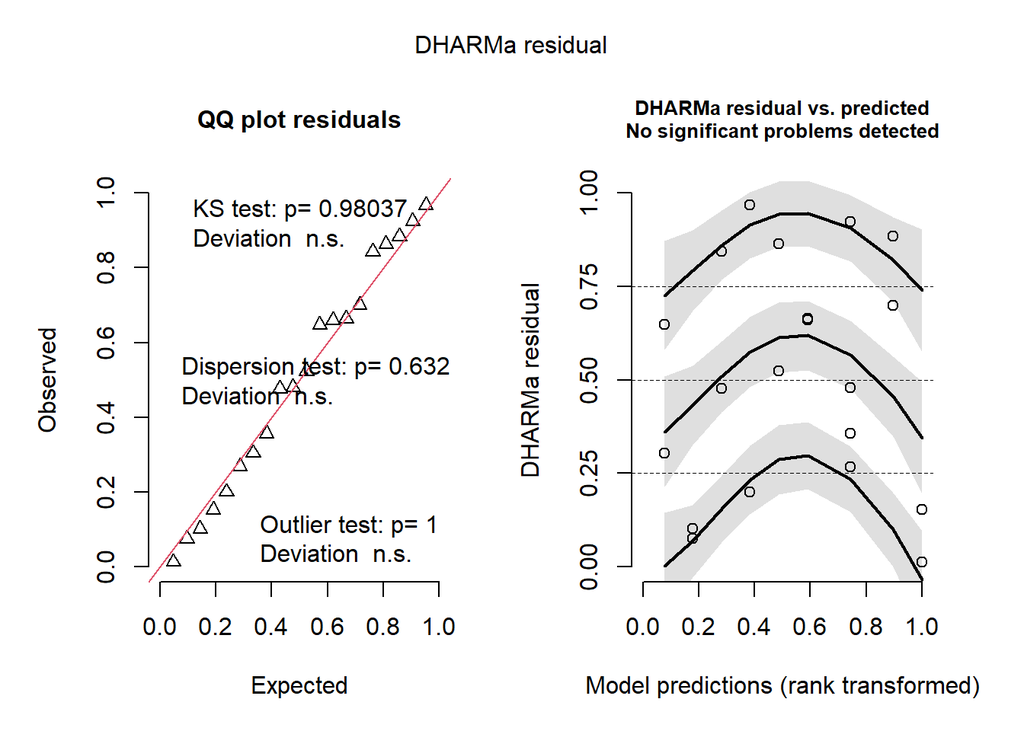

### 6.6 Modelo Rodq1~ProxIE0.5

| Parameter | Coefficient | SE | CI | CI_low | CI_high | z | df_error | p | Component | Effects |
| --- | --- | --- | --- | --- | --- | --- | --- | --- | --- | --- |
| (Intercept) | 1.433281 | 0.9272879 | 0.95 | -0.3841701 | 3.250732 | 1.545670 | Inf | 0.1221844 | conditional | fixed |
| ProxIE0.5 | 32.968227 | 20.1629644 | 0.95 | -6.5504569 | 72.486911 | 1.635088 | Inf | 0.1020305 | conditional | fixed |
| (Intercept) | -2.545323 | 2.1965022 | 0.95 | -6.8503888 | 1.759742 | -1.158808 | Inf | 0.2465346 | zero_inflated | fixed |
| (Intercept) | 1.025895 | NA | 0.95 | 0.6599169 | 1.594837 | NA | NA | NA | dispersion | fixed |

#### 6.6.1 Test dispersión - Modelo Rodq1~ProxIE0.5

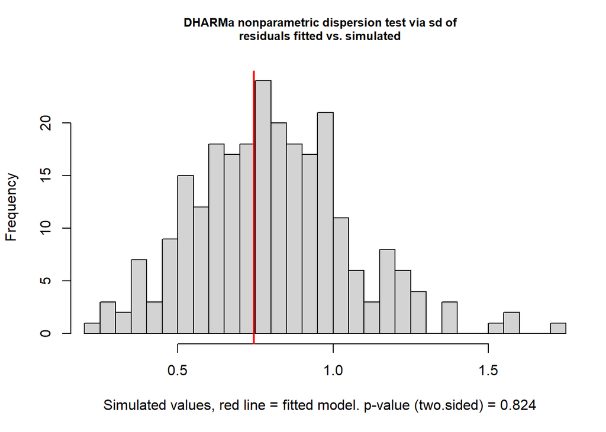

```
    DHARMa nonparametric dispersion test via sd of residuals fitted vs.
    simulated

data:  simulationOutput
dispersion = 0.92726, p-value = 0.824
alternative hypothesis: two.sided
```

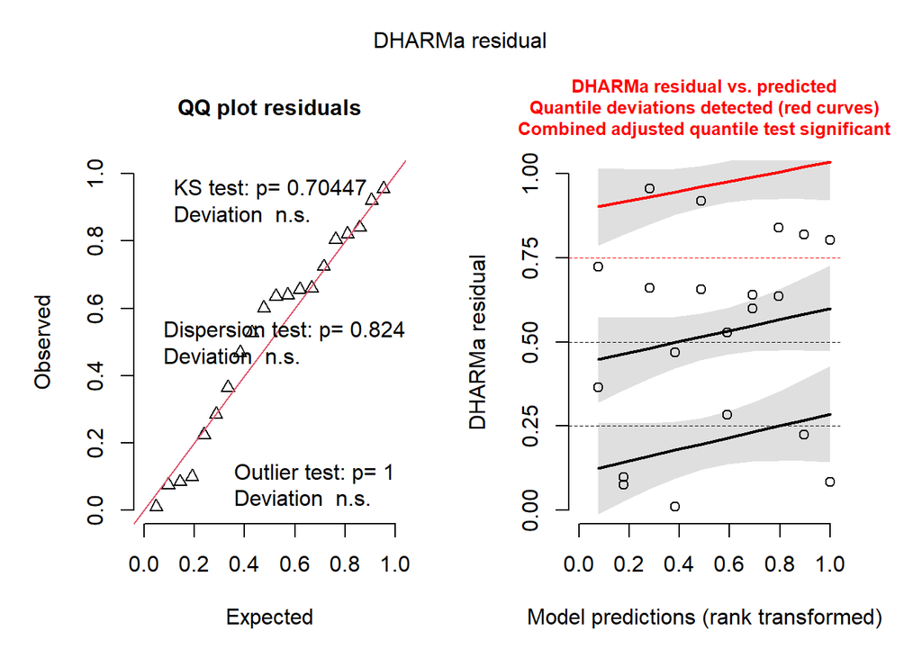